# STAT 385 Homework Assignment 05

Andro Manukov

Due by 12:00 PM 11/16/2019

## HW 5 Problems

Below you will find problems for you to complete as an individual. It is fine to discuss the homework problems with classmates, but cheating is prohibited and will be harshly penalized if detected.

[output not shown]

### 1. Using the **ggplot** function and tidyverse functionality, do the following visualizations:

```r
library(ggrepel)
```

```r
library(faraway)
library(xtable)
library(data.table)
library(usmap)
library(maps)
```

1. recreate your improved visualization in **problem 2a of HW04**

```r
food <- read.csv("Food_Inspections.csv") #reading CVS
food$Color= "white"
food$Color[food$Results == "Pass"] = "chartreuse2" #assigning color based on result of test
food$Color[food$Results == "Fail"] = "red"
```

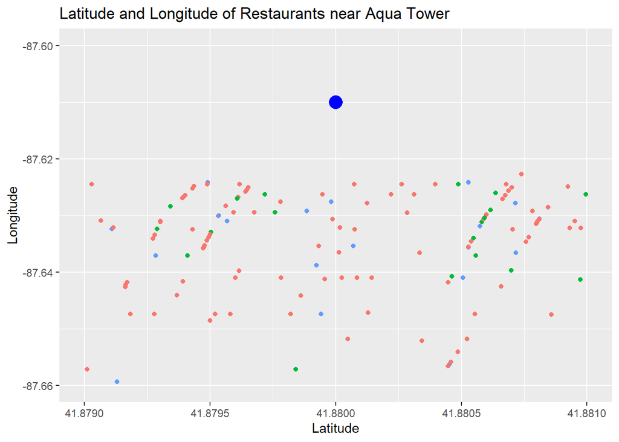

```r
ggplot(data = food) +
  geom_point(mapping = aes(x = Latitude, y = Longitude, color = Color)) +
  geom_point(mapping = aes(x = 41.88, y = -87.61), color = "blue", size = 5) +
  ggtitle("Latitude and Longitude of Restaurants near Aqua Tower") +
  theme(legend.position = "none") +
  labs(color="Pass/Fail") +
  ylim(c(-87.66, -87.6)) +
  xlim(c(41.879, 41.881))
```

2. add a new visually appealing layer to the plot that helps clarify the plot and separately include a short description beneath the plot, such as “Fig. 1 shows…”

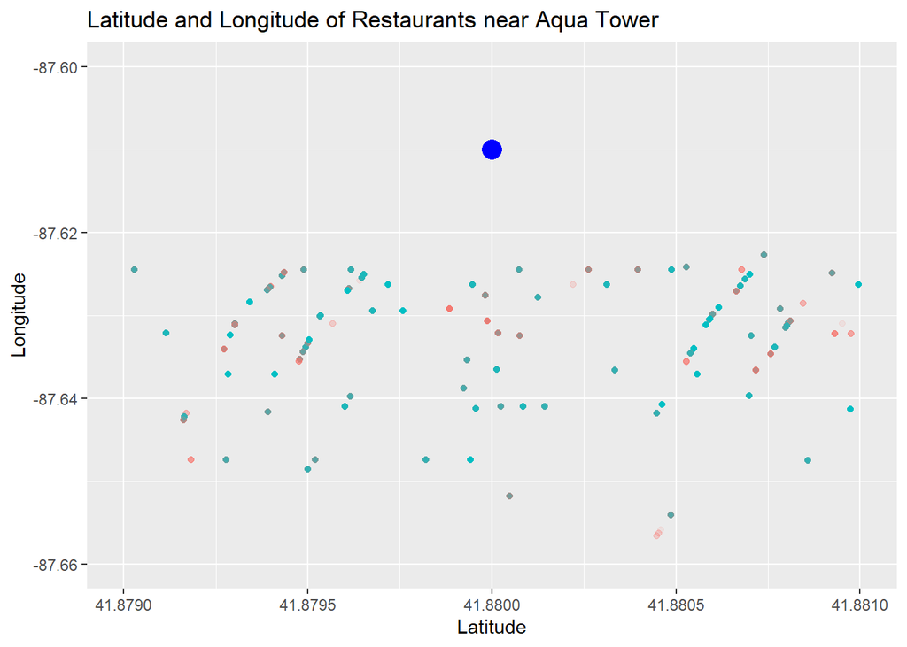

```r
ggplot(data = subset(food, food$Facility.Type == "Restaurant" & food$Color != "white")) +
  geom_point(mapping = aes(x = Latitude, y = Longitude, color = Color, alpha = Color == "chartreuse2")) +
  geom_point(mapping = aes(x = 41.88, y = -87.61), color = "blue", size = 5) +
  ggtitle("Latitude and Longitude of Restaurants near Aqua Tower") +
  theme(legend.position = "none") +
  labs(color="Pass/Fail") +
  ylim(c(-87.66, -87.6)) +
  xlim(c(41.879, 41.881)) +
  scale_alpha_manual(values = c(1, 0.1), guide = FALSE)
```

```r
#changes made:
  #removed clutter by subsetting by restaurants because Gordon Ramsay's brother wants to visit restaurants
  #Removed white points
```

3. recreate your improved visualization in **problem 4a of HW04**

```r
loan <- read.csv("SBA.csv", stringsAsFactors = TRUE)
```

```r
banks = loan[which((loan$Bank == "BUSEY BANK" | loan$Bank == "CENTRAL ILLINOIS BANK A BRANCH" | loan$Bank == "JPMORGAN CHASE BANK NATL ASSOC" | loan$Bank == "PNC BANK, NATIONAL ASSOCIATION" | loan$Bank == "SMALL BUS. GROWTH CORP") & (loan$Zip == 61801 | loan$Zip == 61802 | loan$Zip == 61820 | loan$Zip == 61874)),] #subsetting data

busey = loan[which(loan$Bank == "BUSEY BANK" & (loan$Zip == 61801 | loan$Zip == 61802 | loan$Zip == 61820 | loan$Zip == 61874)),]

central = loan[which(loan$Bank == "CENTRAL ILLINOIS BANK A BRANCH" & (loan$Zip == 61801 | loan$Zip == 61802 | loan$Zip == 61820 | loan$Zip == 61874)),]

chase = loan[which(loan$Bank == "JPMORGAN CHASE BANK NATL ASSOC" & (loan$Zip == 61801 | loan$Zip == 61802 | loan$Zip == 61820 | loan$Zip == 61874)),]

PNC = loan[which(loan$Bank == "PNC BANK, NATIONAL ASSOCIATION" & (loan$Zip == 61801 | loan$Zip == 61802 | loan$Zip == 61820 | loan$Zip == 61874)),]

BUS = loan[which(loan$Bank == "SMALL BUS. GROWTH CORP" & (loan$Zip == 61801 | loan$Zip == 61802 | loan$Zip == 61820 | loan$Zip == 61874)),]

PNC$DisbursementGross = as.numeric(PNC$DisbursementGross) #changing to numeric
PNC$ApprovalFY = as.numeric(PNC$ApprovalFY)

BUS$DisbursementGross = as.numeric(BUS$DisbursementGross)
BUS$ApprovalFY = as.numeric(BUS$ApprovalFY)

chase$DisbursementGross = as.numeric(chase$DisbursementGross)
chase$ApprovalFY = as.numeric(chase$ApprovalFY)

banks$DisbursementGross = as.numeric(banks$DisbursementGross)
banks$ApprovalFY = as.numeric(banks$ApprovalFY)

busey$DisbursementGross = as.numeric(busey$DisbursementGross)
busey$ApprovalFY = as.numeric(busey$ApprovalFY)

central$DisbursementGross = as.numeric(central$DisbursementGross)
central$ApprovalFY = as.numeric(central$ApprovalFY)

banks$Color= "white" #color coding
banks$Color[banks$Bank == "BUSEY BANK"] = "darkblue"
banks$Color[banks$Bank == "CENTRAL ILLINOIS BANK A BRANCH"] = "red"
banks$Color[banks$Bank == "JPMORGAN CHASE BANK NATL ASSOC"] = "lightblue"
banks$Color[banks$Bank == "PNC BANK, NATIONAL ASSOCIATION"] = "purple"
banks$Color[banks$Bank == "SMALL BUS. GROWTH CORP"] = "yellow"
```

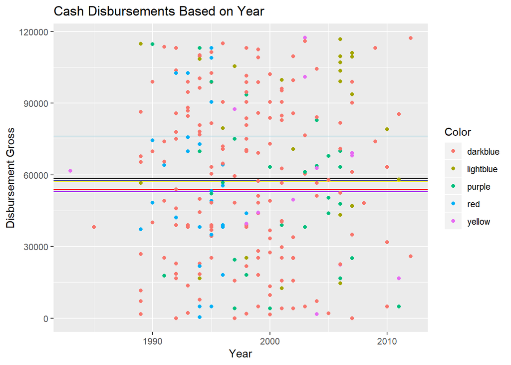

```r
#this data set was derived from SBALoan dataset. using zipcodes near Urbana-Champaign and banks that have more than 10 entries in the SBALoan dataset. (all in HW4)

ggplot(data = banks) +
  geom_hline(yintercept = mean(BUS$DisbursementGross), color = "yellow") +
  geom_hline(yintercept = mean(chase$DisbursementGross), color = "lightblue") +
  geom_hline(yintercept = mean(busey$DisbursementGross), color = "darkblue") +
  geom_hline(yintercept = mean(central$DisbursementGross), color = "red") +
  geom_hline(yintercept = mean(PNC$DisbursementGross), color = "purple") +
  geom_hline(yintercept = mean(banks$DisbursementGross), color = "black") +
  geom_point(mapping = aes(x = ApprovalFY + 1962, y = DisbursementGross, color = Color)) +
  ggtitle("Cash Disbursements Based on Year") +
  xlab("Year") + ylab("Disbursement Gross")
```

4. add a new visually appealing layer to the plot that helps clarify the plot and separately include a short description beneath the plot, such as "Fig. 2 shows…

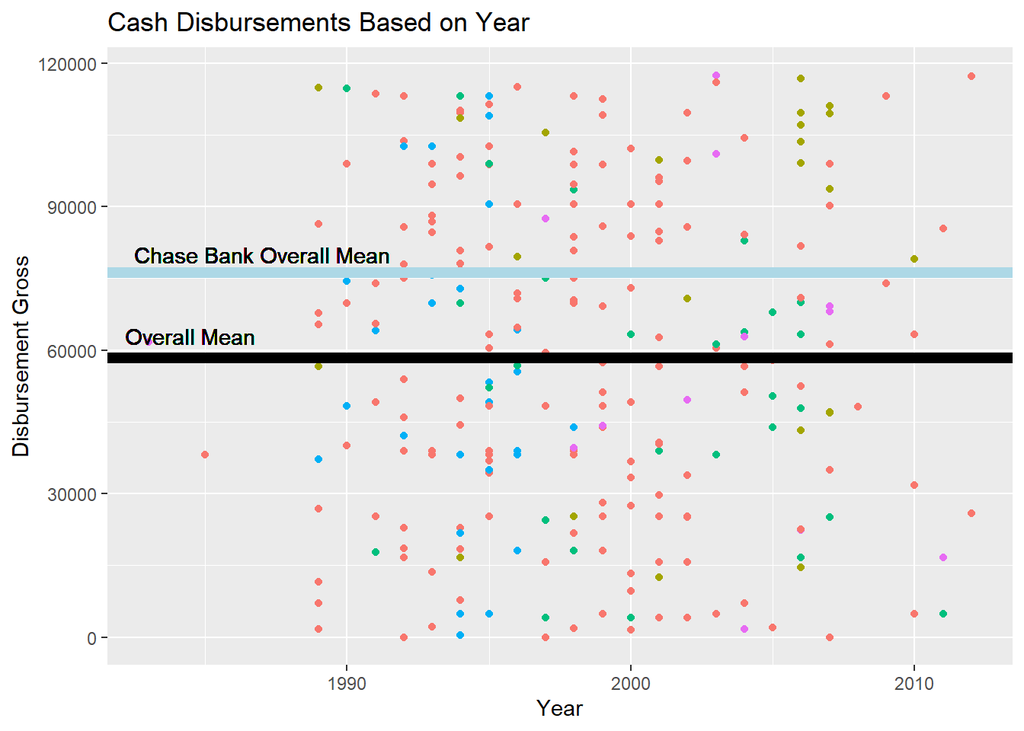

```r
ggplot(data = banks) +
  geom_point(mapping = aes(x = ApprovalFY + 1962, y = DisbursementGross, color = Color)) +
  geom_hline(yintercept = mean(chase$DisbursementGross), color = "lightblue", size = 2.5) +
  geom_hline(yintercept = mean(banks$DisbursementGross), color = "black", size = 2.5) +
  ggtitle("Cash Disbursements Based on Year") +
  xlab("Year") + ylab("Disbursement Gross") +
  geom_text(aes(x = 1987, y = 80000, label = "Chase Bank Overall Mean")) +
  geom_text(aes(x = 1984.5, y = 63000, label = "Overall Mean")) +
  theme(legend.position = "none")
```

Fig 2 Shows a more clear representation on why Chase bank would be better fit for laundering money (when only considering the mean cash disbursements). This new figure removes the clutter of irrelavent banks and essentially combines them into one “Overall Mean” line.

### 2. Successfully import the US Natality Data (for year 2015). The necesssary data links are in the Datasets file on Prof. Kinson’s course website (see [here](https://uofi.box.com/shared/static/kv89ff7n55bkjsxrsx9nlthpl1yocqpo.html)). One is a single csv file 1.9 GB in size. If your computer cannot handle that processing, do use the partitioned version of the data, which are 20 csv files of the same US Natality Data. Here’s a [User Guide](https://uofi.box.com/shared/static/ub0tgcz91z2fpnoc1yazkss5yt2bobhy.pdf) for this data that may help with understanding the data. It might also be helpful for this problem or later problems.

#### **Bonus (worth 5 additional points, i.e. your max HW 05 score could be 15 out of 10): do problem 2 using parallel programming ideas (particularly with foreach) discussed in class. No outside functions/packages other than those discussed in the notes on parallel programming.**

```r
library(parallel)
library(foreach)
library(doParallel)
library(readr)
```

```r
cores <- getDoParWorkers()
cl <- makeCluster(cores)
registerDoParallel(cl)
```

```r
#C:\Users\andre\Desktop\UIUC\Fall2019\STAT385\manukov2\homework\HW5\natfolder
prob2 <- read_csv("natfolder/nat15p1.csv")

TotalNat <- prob2

system.time
({
  foreach(i = 2:20, .combine = rbind) %dopar%
    {
      prob2 <- read_csv(paste("natfolder/nat15p",i,".csv", sep = ""))
      TotalNat <- rbind(TotalNat, prob2)
      rm(prob2)
    }
})
```

### 3. Using the **ggplot** function and tidyverse functionality, recreate or reimagine the following visualizations using the appropriate data. Be sure to use the visual design considerations from Knaflic’s **Storytelling with Data**.

```r
Nat <- read_csv("natfolder/nat15p1.csv")
Nat$MBSTATE_REC <- ifelse(Nat$MBSTATE_REC =="1", "US Born", Nat$MBSTATE_REC) #Renaming var and filtering
Nat$MBSTATE_REC <- ifelse(Nat$MBSTATE_REC =="2", "Outside of US Born", Nat$MBSTATE_REC)
Nat$MBSTATE_REC <- ifelse(Nat$MBSTATE_REC =="3", "Unknown", Nat$MBSTATE_REC)
```

```r
Nat$MCRACEnew = Nat$MRACE15
Nat$MEDUC <- ifelse(Nat$MEDUC == "6", "Bachelors", Nat$MEDUC) #changing numeric values to strings
Nat$MEDUC <- ifelse(Nat$MEDUC == "7", "Masters or Higher", Nat$MEDUC)
Nat$MEDUC <- ifelse(Nat$MEDUC == "8", "Masters or Higher", Nat$MEDUC)

Nat$MRACE6 <- ifelse(Nat$MRACE6 == "1", "White", Nat$MRACE6)
Nat$MRACE6 <- ifelse(Nat$MRACE6 == "2", "Black", Nat$MRACE6)
Nat$MRACE6 <- ifelse(Nat$MRACE6 == "3", "American Indian", Nat$MRACE6)
Nat$MRACE6 <- ifelse(Nat$MRACE6 == "4", "Asian", Nat$MRACE6)
Nat$MRACE6 <- ifelse(Nat$MRACE6 == "5", "Pacific Islanders", Nat$MRACE6)
Nat$MRACE6 <- ifelse(Nat$MRACE6 == "6", "More than one Race", Nat$MRACE6)

Nat$MRACE15 <- ifelse(Nat$MRACE15 == "4", "Asian Indian", Nat$MRACE15)
Nat$MRACE15 <- ifelse(Nat$MRACE15 == "5", "Chinese", Nat$MRACE15)
Nat$MRACE15 <- ifelse(Nat$MRACE15 == "6", "Filipino", Nat$MRACE15)
Nat$MRACE15 <- ifelse(Nat$MRACE15 == "7", "Japanese", Nat$MRACE15)
Nat$MRACE15 <- ifelse(Nat$MRACE15 == "8", "Korean", Nat$MRACE15)
Nat$MRACE15 <- ifelse(Nat$MRACE15 == "9", "Vietnamese", Nat$MRACE15)
```

1. The image below uses the US Natlity Data. Also, explain the image with Markdown syntax.

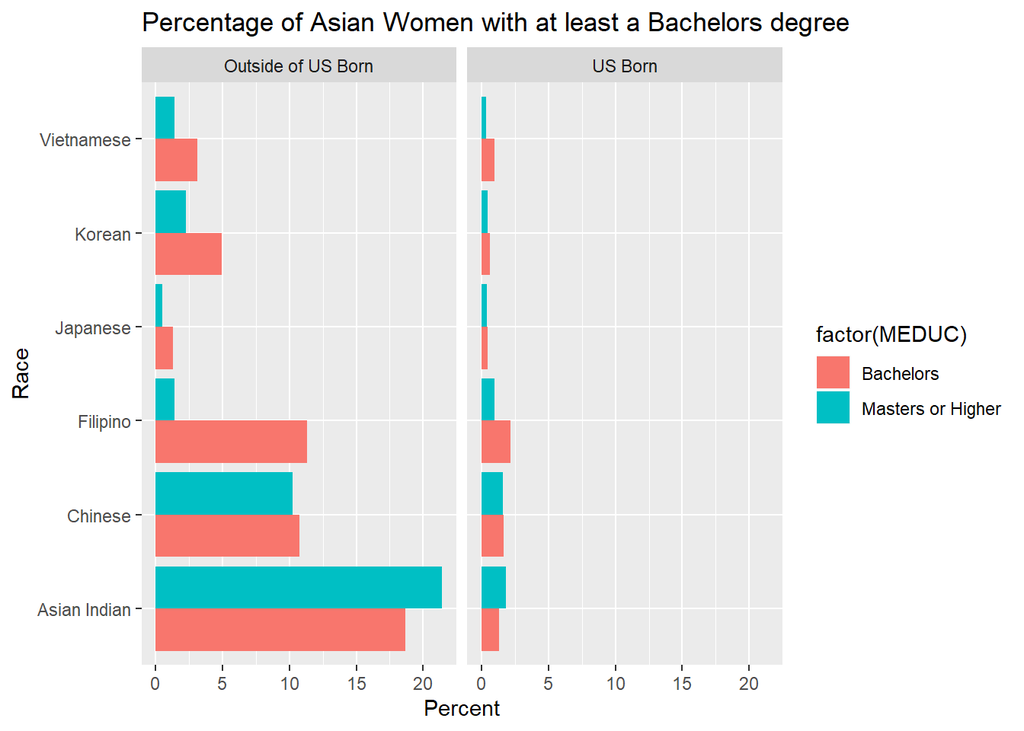

```r
#Using the whole dataset literally crashes everything so im using the first parititon
ggplot(data = subset(Nat, (Nat$MEDUC == "Bachelors" | Nat$MEDUC == "Masters or Higher") & (Nat$MBSTATE_REC == "US Born" | Nat$MBSTATE_REC == "Outside of US Born") & (Nat$MRACE15 == "Asian Indian" | Nat$MRACE15 == "Chinese" | Nat$MRACE15 == "Filipino" | Nat$MRACE15 == "Japanese" | Nat$MRACE15 == "Korean" | Nat$MRACE15 == "Vietnamese"))) +
  coord_flip() +
  geom_bar(mapping = aes(x = factor(MRACE15), y = 100 * (..count..)/sum(..count..), fill=factor(MEDUC)), position = "dodge") +
  facet_wrap( ~ factor(MBSTATE_REC)) +
  ylab("Percent") + xlab("Race") + ggtitle("Percentage of Asian Women with at least a Bachelors degree")
```

I decided to switch a few things compared to the original image. For 1, I decided to compare the bars side by side instead of stacked on each other. I think the stacked format lessens the readability of a barchart. Secondly, I decided to split the bar graphs into 2 different bar graphs with a more clear divider between US born and Not US born. I think this is better than the original format since its easier to compare the results between US born Asian Mothers and Non-US Born Asian Mothers.

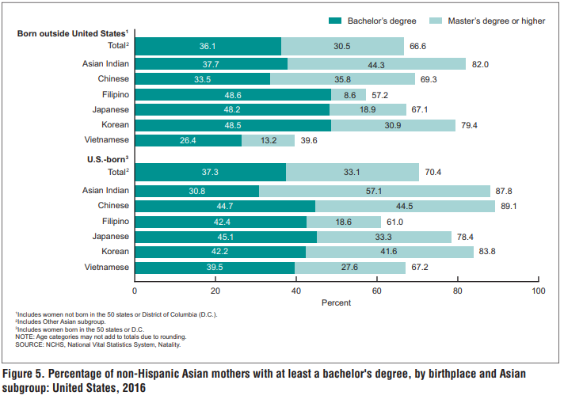

2. The image below uses the US Natlity Data. Also, explain the image with Markdown syntax (do not include the explanation within the visualization).

```r
Nat$isOver40 <- ifelse(Nat$MAGER >= 40, "40 and Over", "30 through 39") #over40 variable.
```

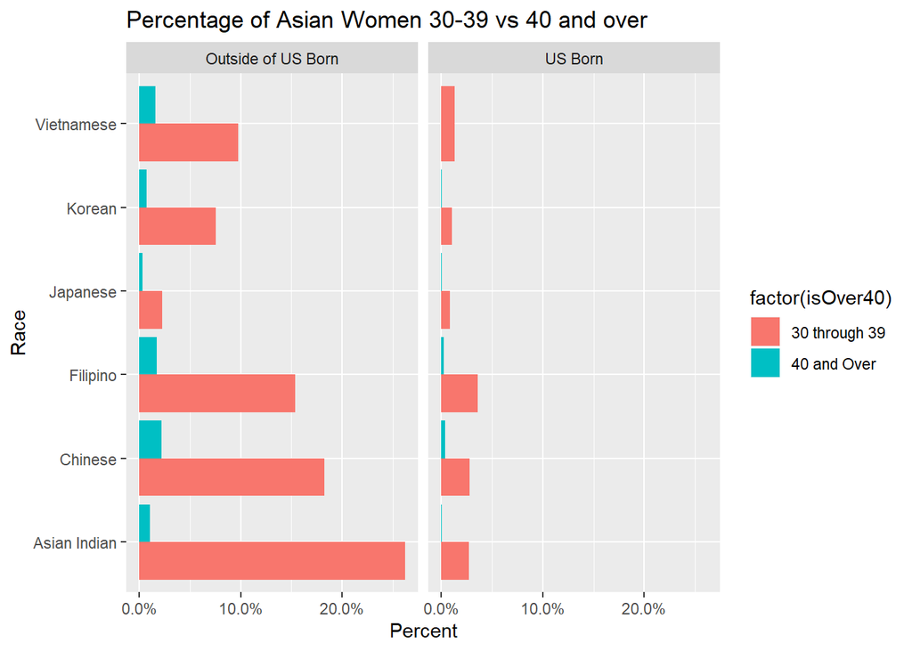

```r
#Using the whole dataset literally crashes everything so im using the first parititon
ggplot(data = subset(Nat, (Nat$MAGER >= 30) & (Nat$MBSTATE_REC == "US Born" | Nat$MBSTATE_REC == "Outside of US Born") & (Nat$MRACE15 == "Asian Indian" | Nat$MRACE15 == "Chinese" | Nat$MRACE15 == "Filipino" | Nat$MRACE15 == "Japanese" | Nat$MRACE15 == "Korean" | Nat$MRACE15 == "Vietnamese"))) +
  coord_flip() +
  geom_bar(mapping = aes(x = factor(MRACE15), y = (..count..)/sum(..count..), fill=factor(isOver40)), position = "dodge") +
  facet_wrap( ~ factor(MBSTATE_REC)) +
  scale_y_continuous(labels = scales::percent) +
  ylab("Percent") + xlab("Race") + ggtitle("Percentage of Asian Women 30-39 vs 40 and over")
```

I took a similar approach to this bar graph as I did with the previous one. This image is a bar graph comparing the percentage of Asian Mothers over 30 and under 40 with those who are over 40. While stacking the barplot does not look as confusing as the previous graph, I think doing a side-by-side is still more clear. Additionally, I split the bar graph into two parts, US Born and Non-US Born.

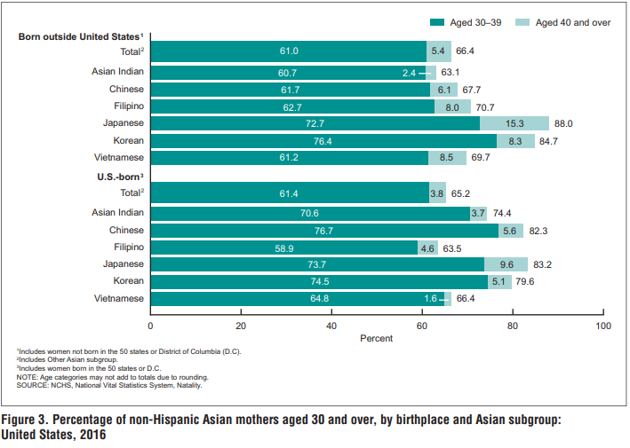

3. The image below uses the Chicago Food Inspections Data [link here](https://uofi.box.com/shared/static/5637axblfhajotail80yw7j2s4r27hxd.csv). Also, explain the image with Markdown syntax (do not include the explanation within the visualization).

```r
food$Inspection.Date <-as.character(food$Inspection.Date)
```

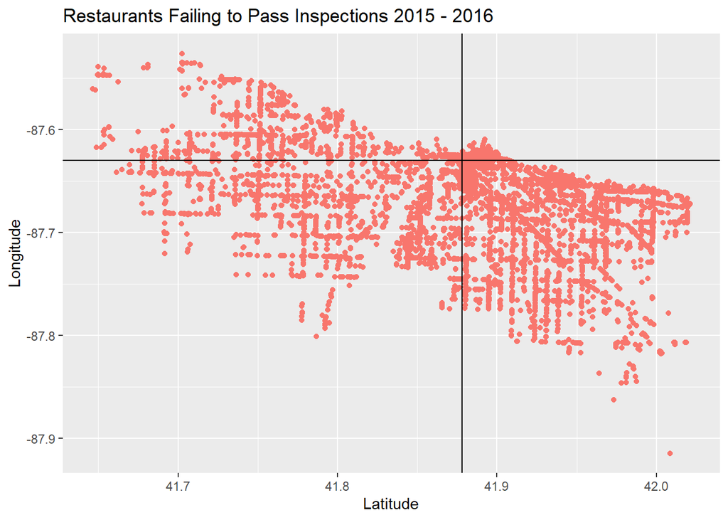

```r
ggplot(data = subset(food, food$Color == "red" & food$Inspection.Date >= "1/1/2015" & food$Inspection.Date <= "12/31/2016")) +
  geom_point(mapping = aes(x = Latitude, y = Longitude, color = Color)) +
  ggtitle("Restaurants Failing to Pass Inspections 2015 - 2016") +
  theme(legend.position = "none") +
  labs(color="Pass/Fail") +
  geom_hline(yintercept=-87.6298) + #Chicago center
  geom_vline(xintercept=41.8781)
```

This one is pretty simple, the red dots are all restaurants that failed inspection and the cross section of the two lines is the center of chicago. It is a barebones version of the graph below.

[figure not shown]

4. The image below uses the Chicago Food Inspections Data. Also, explain the image with Markdown syntax (do not include the explanation within the visualization).

```r
food$Year = format(as.Date(food$Inspection.Date, format="%m/%d/%Y"),"%Y")
food$Year = as.integer(food$Year)
```

[figure not shown]

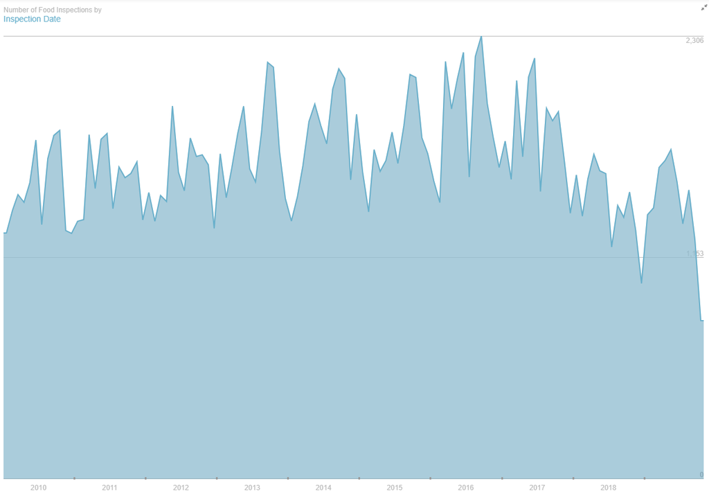

```r
ggplot(data = food, aes(x = food$Inspection.Date))
```

### 4. Do the following:

Redo problem 3 in **HW03** using the parallel programming. Does parallel computing perform the tasks in parts **c** and **e** faster than the method that you used in **HW03**? Show your work including the runtimes for the un-parallelized and parallelized versions.

```r
part4df = read_csv("https://uofi.box.com/shared/static/mwntzgp2rvyewf292k6i62pykjz1onnw.csv")
colnames(part4df)[colnames(part4df) == "unknown1"] <- "x" #renaming first col to x
se <- function(x) sd(x) / sqrt(length((x))) #creating SE function
statisticX = (mean(part4df$x) - 10) / se(part4df$x)

#partCPara
#resamples <- rep(0,10000)
trials = 10000

results <- data.frame()
part_c_not_para <- system.time({
  trial <- 1
  while(trial <= trials)
  {
    j <- sample(part4df$x, replace = TRUE);
    result1 <- (mean(j) - mean(part4df$x)) / se(j)
    results <- rbind(results, result1)
    trial <- trial + 1
  }
})

colnames(part4df)[colnames(part4df) == "unknown2"] <- "y" #renaming second col to y
statisticSecond = (mean(part4df$y) - 10) / se(part4df$y)

results2 <- data.frame()
part_e_not_para <- system.time({
  trial <- 1
  while(trial <= trials)
  {
    j <- sample(part4df$y, replace = TRUE);
    result1 <- (mean(j) - mean(part4df$y)) / se(j)
    results <- rbind(results2, result1)
    trial <- trial + 1
  }
})



print(part_c_not_para)
```

```
##    user  system elapsed
##    3.28    0.45    3.77
```

```r
print(part_e_not_para)
```

```
##    user  system elapsed
##    5.43    0.00    5.44
```

```r
sample_fn <- function(trial) {
  j <- sample(part4df$y, replace = TRUE);
  result1 <- (mean(j) - mean(part4df$y)) / se(j)
  results <- rbind(results2, result1)
}

sample_fn_part_c <- function(trial) {
  j <- sample(part4df$y, replace = TRUE);
  result1 <- (mean(j) - mean(part4df$x)) / se(j)
  results <- rbind(results2, result1)
}
```

```r
part_e_para <- system.time({
  results3 <- mclapply(trials, sample_fn, mc.cores = 1)
})

part_c_para <- system.time({
  results4 <- mclapply(trials, sample_fn_part_c, mc.cores = 1)
})


print(part_c_para)
```

```
##    user  system elapsed
##       0       0       0
```

```r
print(part_e_para)
```

```
##    user  system elapsed
##       0       0       0
```

### 5. Problem in parallel coding

1. Install the **conformal.glm** R package which can be found at https://github.com/DEck13/conformal.glm.

Run the following code:

```r
library(devtools)
install_github(repo = "DEck13/conformal.glm", subdir="conformal.glm")
library(HDInterval)
library(MASS)
library(parallel)
library(conformal.glm)
set.seed(13)
n <- 250
# generate predictors
x <- runif(n)
# set regression coefficient vector
beta <- c(3, 5)
# generate responses from a linear regression model
y <- rnorm(n, mean = cbind(1, x) %*% beta, sd = 3)
# store predictors and responses as a dataframe
dat <- data.frame(y = y, x = x)
# fit linear regression model
model <- lm(y ~ x, data = dat)
# obtain OLS estimator of beta
betahat <- model$coefficients
# convert predictors into a matrix
Xk <- as.matrix(x, nrow = n)
# extract internal model information, this is necessary for the assignment
call <- model$call
formula <- call$formula
family <- "gaussian"
link <- "identity"
newdata.formula <- as.matrix(model.frame(formula, as.data.frame(dat))[, -1])
# This function takes on a new (x,y) data point and reports a
# value corresponding to how similar this new data point is
# with the data that we generated, higher numbers are better.
# The goal is to use this function to get a range of new y
# values that agrees with our generated data at each x value in
# our generated data set.
density_score <- function(ynew, xnew){
  rank(phatxy(ynew = ynew, xnew = xnew, Yk = y, Xk = Xk, xnew.modmat = xnew,
    data = dat, formula = formula, family = family, link = link))[n+1]
}
# We try this out on the first x value in our generated data set.
# In order to do this we write two line searches
xnew <- x[1]
# start line searches at the predicted response value
# corresponding to xnew
ystart <- ylwr <- yupr <- as.numeric(c(1,xnew) %*% betahat)
score <- density_score(ynew = ystart, xnew = xnew)
# line search 1: line search that estimates the largest y
# value corresponding to the first x value that agrees with
# our generated data
while(score > 13){
  yupr <- yupr + 0.01
  score <- density_score(ynew = yupr, xnew = xnew)
}
# line search 2: line search that estimates the smallest y
# value corresponding to the first x value that agrees with
# our generated data
score <- density_score(ynew = ystart, xnew = xnew)
while(score > 13){
  ylwr <- ylwr - 0.01
  score <- density_score(ynew = ylwr, xnew = xnew)
}
```

2. Write a function which runs the two line searches in part **a** for the jth generated predictor value.

```r
line_1 <- function()
{
  yupr <- yupr + 0.01
  score <- density_score(ynew = yupr, xnew = xnew)
}


line_2 <- function()
{
  ylwr <- ylwr - 0.01
  score <- density_score(ynew = ylwr, xnew = xnew)
}
```

3. Use parallel programming to run the function you wrote in part **b**. Save the output and record the time that it took to perform these calculations *NOTE: It is not advised to use `detectCores` as an argument in defining the number of workers you want. It’s much better to specify the number of workers explicitly.*

```r
 line_1_time <- system.time({
   mclapply(13, line_1, mc.cores = 1)
 })
```

```
## Error in FUN(X[[i]], ...): unused argument (X[[i]])
```

```
## Timing stopped at: 0 0 0
```

```r
 lime_2_time <- system.time({
   mclapply(13, line_2, mc.cores = 1)
 })
```

```
## Error in FUN(X[[i]], ...): unused argument (X[[i]])
```

```
## Timing stopped at: 0 0 0
```

4. Redo the calculation in part **c** using `lapply` and record the time it took to run this job. Which method is faster?

```r
l_time <- system.time({
  lapply(13, line_1)
})
```

```
## Error in FUN(X[[i]], ...): unused argument (X[[i]])
```

```
## Timing stopped at: 0 0 0
```

```r
l_time_2 <- system.time({
  lapply(13, line_2)
})
```

```
## Error in FUN(X[[i]], ...): unused argument (X[[i]])
```

```
## Timing stopped at: 0 0 0
```